# Willamette Basin Subwatershed Funding

Teague Tran

8/5/2021

```r
library(tidyverse)
library(ggplot2)
library(janitor)
library(readxl)
library(here)
library(kableExtra)
library(lubridate)
library(tsibble)
library(patchwork)
library(reshape2)
library(hrbrthemes)

watershed_funding <- read_xls(here("Projects_by_subwatersheds.xls")) %>%
  clean_names()
```

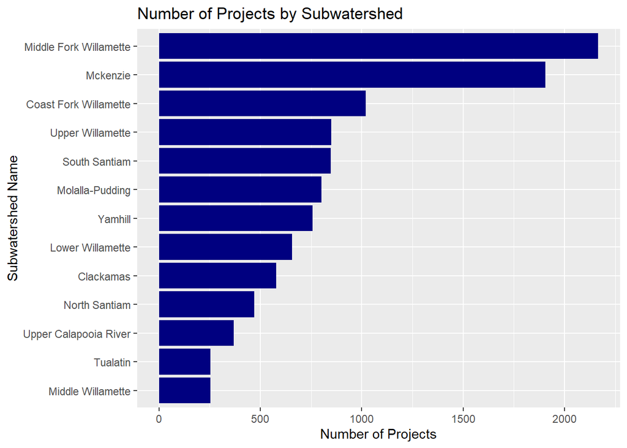

```r
#number of projects by subwatershed
project_counts_watershed <- watershed_funding %>%
  group_by(name_2) %>%
  count()
#visualize the counts
ggplot(data = project_counts_watershed) +
  geom_col(aes(x = reorder(name_2,n), y = n), fill ="navy") +
  coord_flip() +
  labs(title = "Number of Projects by Subwatershed", x = "Subwatershed Name", y = "Number of Projects")
```

```r
#seperate from # of projects funded by each because there's only funding information on ~4,000 of them
```

**Figure 1. Willamette Basin restoration projects from 1990 through 2012** are shown here. Many restoration projects fall within the Middle Fork Willamette and McKenzie subbasin (2165 and 1906 projects respectively). Meanwhile, The Tualatin and Middle Willamette have received the least projects within the time frame (255 and 254 projects respectively). It should be noted that 3,244 out of 10,930 had starting date information, so there could be some projects depicted here that were started outside of the time frame.

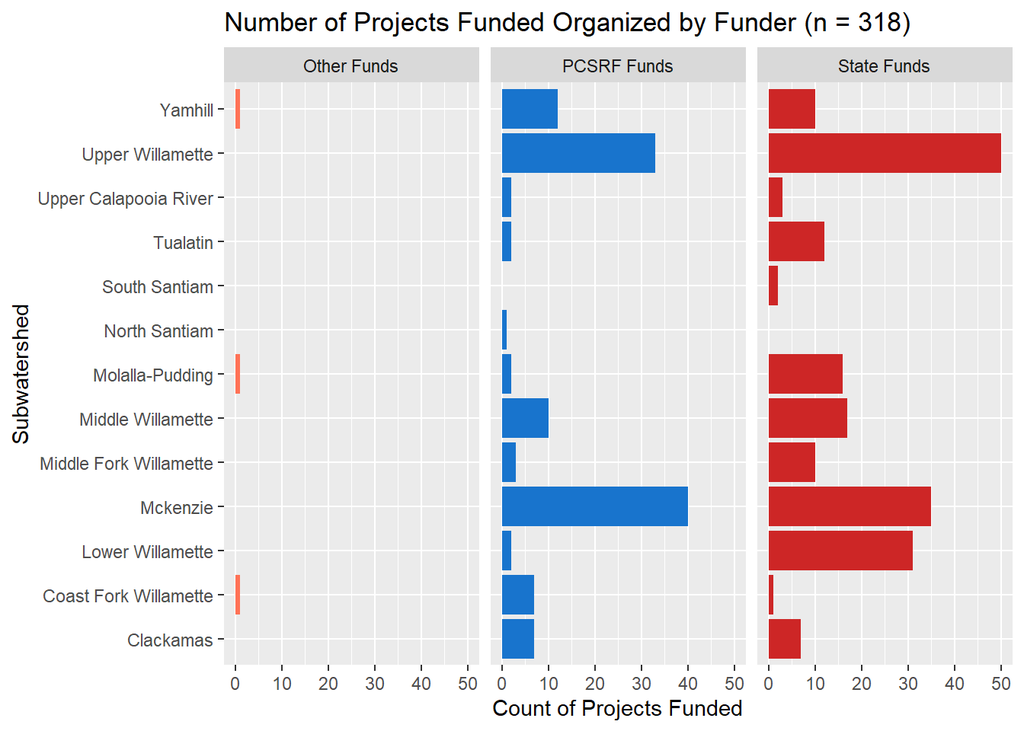

```r
#get the counts of projects that have been funded
project_counts_by_funder <- watershed_funding %>%
  select(name_2, pcsrf_funds, state_funds, other_funds) %>%
  filter(pcsrf_funds > 0 | state_funds > 0 | other_funds > 0) #filter out only the projects that have at least 1 source of funding

pivot_funder_counts <- pivot_longer(project_counts_by_funder, c(pcsrf_funds, state_funds, other_funds)) #pivot to make it easier to graph
#change column names
colnames(pivot_funder_counts) <- c("watershed_name", "funder", "amount_funded")
#take out any project/funder combos with 0 funding
pivot_funder_counts <-  pivot_funder_counts %>%
  filter(amount_funded > 0)
#group by watershed and funder
funder_counts <- pivot_funder_counts %>%
  group_by(watershed_name,funder) %>%
  count()
#replace names to make it prettier on graph
funder_counts$funder <-
  sub( "pcsrf_funds", "PCSRF Funds", funder_counts$funder)

funder_counts$funder <-
  sub( "state_funds", "State Funds", funder_counts$funder)

funder_counts$funder <-
  sub( "other_funds", "Other Funds", funder_counts$funder)
#GRAPH THAT BAD BOY/GIRL/PERSON/THING
ggplot(data = funder_counts) +
  geom_col(data = funder_counts, aes(x = watershed_name, y = n, fill = funder)) +
  facet_wrap(~funder)+
  coord_flip() +
  labs(title = "Number of Projects Funded Organized by Funder (n = 318)", x = "Subwatershed", y = "Count of Projects Funded") +
  theme(legend.position = "none") +
  scale_fill_manual(values = c("coral1", "dodgerblue3", "firebrick3"))
```

```r
#putting all of the types of funding into data frame to perform summary statistics
rows_funding <- watershed_funding %>%
  select(pcsrf_funds, state_funds, other_funds, in_kind_volunteer_funds, in_kind_donated_labor_funds, in_kind_other_funds)
#get dates for the start of funding
watershed_funding_withdates <-  watershed_funding %>%
  mutate(start_date = lubridate::ymd(start)) %>%
  mutate(year_start = year(start_date)) %>%
  mutate(total_money = rowSums(rows_funding))

#how many with actual dates
actual_dates  <- watershed_funding_withdates %>%
  filter (!is.na(start_date))

#sum of total funding by subwatershed
watershed_money_sum <- watershed_funding_withdates %>%
  group_by(name_2) %>%
  summarise(round(sum(total_money),2))
#mean of total
watershed_money_mean <- watershed_funding_withdates %>%
  filter(total_money > 0, is.na = TRUE ) %>%
  group_by(name_2) %>%
  summarise(round(mean(total_money),2))
#median of total
watershed_money_median <- watershed_funding_withdates %>%
  filter(total_money > 0, is.na = TRUE ) %>%
  group_by(name_2) %>%
  summarise(round(mean(total_money),2))

#sum of NOAA (PCSRF)funds
pcsrf_funds_sum <- watershed_funding_withdates %>%
  group_by(name_2) %>%
  summarise(round(sum(pcsrf_funds),2))
#mean of NOAA
pcsrf_funds_mean  <- watershed_funding_withdates %>%
  filter(pcsrf_funds > 0, is.na = TRUE ) %>%
  group_by(name_2) %>%
  summarise(round(mean(pcsrf_funds),2))
#median of NOAA
pcsrf_funds_median  <- watershed_funding_withdates %>%
  filter(pcsrf_funds > 0, is.na = TRUE ) %>%
  group_by(name_2) %>%
  summarise(round(median(pcsrf_funds),2))

#sum of state funds
state_funds_sum <- watershed_funding_withdates %>%
  group_by(name_2) %>%
  summarise(round(sum(state_funds),2))

#mean of state funds
state_funds_mean <- watershed_funding_withdates %>%
  filter(state_funds > 0, is.na = TRUE ) %>%
  group_by(name_2) %>%
  summarise(round(mean(state_funds),2))

#median of state funds
state_funds_median <- watershed_funding_withdates %>%
  filter(state_funds > 0, is.na = TRUE ) %>%
  group_by(name_2) %>%
  summarise(round(median(state_funds),2))
#sum of other funds (all in-kind funds = 0)
others_funds_sum <- watershed_funding_withdates %>%
  group_by(name_2) %>%
  summarise(round(sum(other_funds),2))

#make column names easier
colnames(watershed_money_sum) <- c("watershed_name", "money_funded_sum")
colnames(watershed_money_mean) <- c("watershed_name", "money_funded_mean")
colnames(watershed_money_median) <- c("watershed_name", "money_funded_median")
colnames(pcsrf_funds_sum) <- c("watershed_name", "money_funded_sum_pcsrf")
colnames(pcsrf_funds_mean) <- c("watershed_name", "money_funded_mean_pcsrf")
colnames(pcsrf_funds_median) <- c("watershed_name", "money_funded_median_pcsrf")
colnames(state_funds_sum) <- c("watershed_name", "money_funded_sum_state")
colnames(state_funds_mean) <- c("watershed_name", "money_funded_mean_state")
colnames(state_funds_median) <- c("watershed_name", "money_funded_median_state")
colnames(others_funds_sum) <- c("watershed_name", "money_funded_sum_others")

# divide by 1000 to make numbers more managable
watershed_money_sum <- watershed_money_sum %>%
  mutate(divided_1000_sum = round(money_funded_sum/1000,2))
watershed_money_mean <- watershed_money_mean %>%
  mutate(divided_1000_mean = round(money_funded_mean/1000,2))
watershed_money_median <- watershed_money_median %>%
  mutate(divided_1000_median = round(money_funded_median/1000,2))
pcsrf_funds_sum <- pcsrf_funds_sum %>%
  mutate(divided_1000_pcsrf_sum = round(money_funded_sum_pcsrf/1000,2))
pcsrf_funds_mean <- pcsrf_funds_mean %>%
  mutate(divided_1000_pcsrf_mean = round(money_funded_mean_pcsrf/1000,2))
pcsrf_funds_median <- pcsrf_funds_median %>%
  mutate(divided_1000_pcsrf_median = round(money_funded_median_pcsrf/1000,2))
state_funds_sum <- state_funds_sum %>%
  mutate(divided_1000_state_sum = round(money_funded_sum_state/1000,2))
state_funds_mean <- state_funds_mean %>%
  mutate(divided_1000_state_mean = round(money_funded_mean_state/1000,2))
state_funds_median<- state_funds_median %>%
  mutate(divided_1000_state_median = round(money_funded_median_state/1000,2))
others_funds_sum <- others_funds_sum %>%
  mutate(divided_1000_others_sum = round(money_funded_sum_others/1000,2))

mymerge <- function(x, y)
merge(x, y, by=c("watershed_name"), all=TRUE)

combined_funds_df <- Reduce(mymerge, list(watershed_money_sum, watershed_money_mean, watershed_money_median, pcsrf_funds_sum, pcsrf_funds_mean, pcsrf_funds_median,state_funds_sum, state_funds_mean, state_funds_median, others_funds_sum))
```

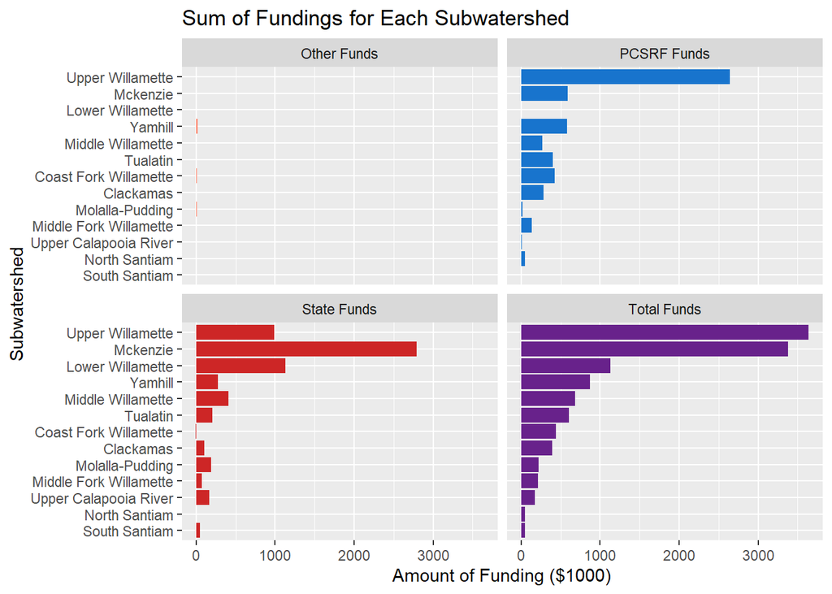

```r
#Organize data frame into usable columns to pivot
showing_sums <- combined_funds_df %>%
  select(watershed_name, divided_1000_sum,divided_1000_pcsrf_sum, divided_1000_state_sum, divided_1000_others_sum)

#PIVOT!!! PIVVVOOOOOTTTT
pivot_sums <- pivot_longer(showing_sums, c(divided_1000_sum,divided_1000_pcsrf_sum, divided_1000_state_sum, divided_1000_others_sum))

#make more coherent column names
colnames(pivot_sums) <- c("watershed_name","funding_type", "money_funded_sum")
#Change all funding types to more presentable names
pivot_sums$funding_type <-
  sub( "divided_1000_pcsrf_sum", "PCSRF Funds", pivot_sums$funding_type)

pivot_sums$funding_type <-
  sub( "divided_1000_sum", "Total Funds", pivot_sums$funding_type)

pivot_sums$funding_type <-
  sub( "divided_1000_state_sum", "State Funds", pivot_sums$funding_type)

pivot_sums$funding_type <-
  sub( "divided_1000_others_sum", "Other Funds", pivot_sums$funding_type)

ggplot(data = pivot_sums)+
  geom_col(aes(x = reorder(watershed_name, money_funded_sum), y = money_funded_sum, fill = funding_type)) +
  theme(legend.position = "none", axis.text = element_text(size = 8.75))+
  coord_flip() +
  facet_wrap(~funding_type) +
  labs(x = "Subwatershed", y = "Amount of Funding ($1000)", title = "Sum of Fundings for Each Subwatershed") +
  scale_fill_manual(values = c("coral1", "dodgerblue3", "firebrick3", "darkorchid4"))
```

**Figure 3. Projects that were funded by PCSRF, State or other funds** show that PCSRF funds primarily focus on Upper Willamette (~$2.6 million) and state funds focused on McKenzie (~$2.8 million), leading them to be the most well-funded. Meanwhile, North Santiam and South Santiam are the least funded (~$50 thousand and $46 thousand respectively).

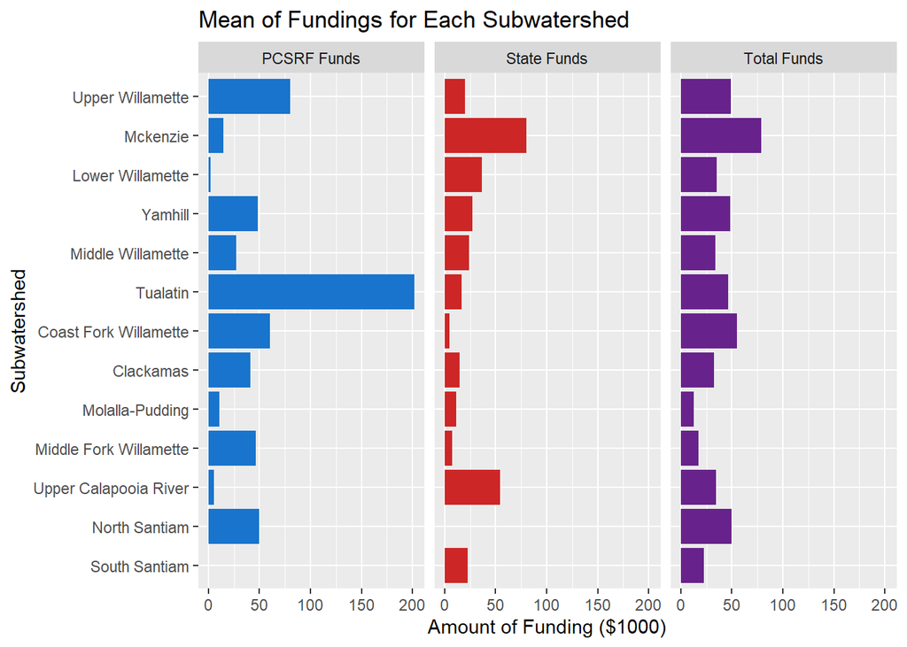

```r
#Organize data frame into usable columns to pivot
showing_means <- combined_funds_df %>%
  select(watershed_name, divided_1000_mean,divided_1000_pcsrf_mean, divided_1000_state_mean)

#PIVOT!!! PIVVVOOOOOTTTT
pivot_means <- pivot_longer(showing_means, c(divided_1000_mean,divided_1000_pcsrf_mean, divided_1000_state_mean))
#make more coherent column names

colnames(pivot_means) <- c("watershed_name","funding_type", "money_funded_mean")
#Change all funding types to more presentable names
pivot_means$funding_type <-
  sub( "divided_1000_pcsrf_mean", "PCSRF Funds", pivot_means$funding_type)

pivot_means$funding_type <-
  sub( "divided_1000_mean", "Total Funds", pivot_means$funding_type)

pivot_means$funding_type <-
  sub( "divided_1000_state_mean", "State Funds", pivot_means$funding_type)

#get watersheds into the order as sums
pivot_means$watershed_name <-factor(pivot_means$watershed_name, ordered = T, levels =  c("South Santiam", "North Santiam", "Upper Calapooia River", "Middle Fork Willamette", "Molalla-Pudding", "Clackamas", "Coast Fork Willamette", "Tualatin", "Middle Willamette", "Yamhill", "Lower Willamette", "Mckenzie", "Upper Willamette"))

#Graph it!
ggplot(data = pivot_means)+
  geom_col(aes(x = watershed_name, y = money_funded_mean, fill = funding_type)) +
  theme(legend.position = "none", axis.text = element_text(size = 8.75))+
  coord_flip() +
  facet_wrap(~funding_type) +
  labs(x = "Subwatershed", y = "Amount of Funding ($1000)", title = "Mean of Fundings for Each Subwatershed") +
  scale_fill_manual(values = c( "dodgerblue3", "firebrick3", "darkorchid4"))
```

**Figure 4. Mean funding for each subwatershed** show that Tualatin receives the highest PCSRF funding per project. However, this could be due to the low amount of projects funded by PCSRF there. Meanwhile, both the state and total funding shows that the McKenzie receives the most per project.

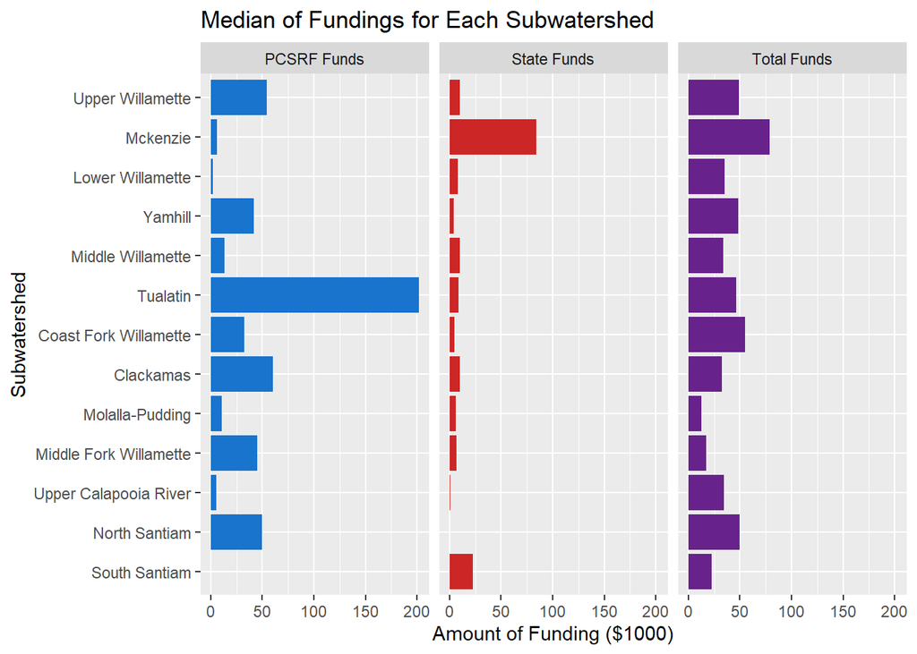

```r
#Organize data frame into usable columns to pivot
showing_medians <- combined_funds_df %>%
  select(watershed_name, divided_1000_median,divided_1000_pcsrf_median, divided_1000_state_median)

#PIVOT!!! PIVVVOOOOOTTTT
pivot_medians <- pivot_longer(showing_medians, c(divided_1000_median,divided_1000_pcsrf_median, divided_1000_state_median))
#make more coherent column names

colnames(pivot_medians) <- c("watershed_name","funding_type", "money_funded_mean")
#Change all funding types to more presentable names
pivot_medians$funding_type <-
  sub( "divided_1000_pcsrf_median", "PCSRF Funds", pivot_medians$funding_type)

pivot_medians$funding_type <-
  sub( "divided_1000_median", "Total Funds", pivot_medians$funding_type)

pivot_medians$funding_type <-
  sub( "divided_1000_state_median", "State Funds", pivot_medians$funding_type)

#get watersheds into the order as sums
pivot_medians$watershed_name <-factor(pivot_medians$watershed_name, ordered = T, levels =  c("South Santiam", "North Santiam", "Upper Calapooia River", "Middle Fork Willamette", "Molalla-Pudding", "Clackamas", "Coast Fork Willamette", "Tualatin", "Middle Willamette", "Yamhill", "Lower Willamette", "Mckenzie", "Upper Willamette"))

#Graph it!
ggplot(data = pivot_medians)+
  geom_col(aes(x = watershed_name, y = money_funded_mean, fill = funding_type)) +
  theme(legend.position = "none", axis.text = element_text(size = 8.75))+
  coord_flip() +
  facet_wrap(~funding_type) +
  labs(x = "Subwatershed", y = "Amount of Funding ($1000)", title = "Median of Fundings for Each Subwatershed") +
  scale_fill_manual(values = c( "dodgerblue3", "firebrick3", "darkorchid4"))
```

```r
# #time for type of funding
# restoration_types <- watershed_funding %>%
#   select(type_s_23, pcsrf_funds, state_funds, other_funds,name_2) %>%
#   filter(pcsrf_funds > 0 | state_funds > 0 | other_funds > 0)
#
# restoration_types_pivot <-pivot_longer(restoration_types, c(pcsrf_funds, state_funds, other_funds)) #pivot to make it easier to graph
#
# #change column names
# colnames(restoration_types_pivot) <- c("restoration_type", "watershed_name", "funder", "amount_funded")
#
# #replace names to make it prettier on graph
# restoration_types_pivot$funder <-
#   sub( "pcsrf_funds", "PCSRF Funds", restoration_types_pivot$funder)
#
# restoration_types_pivot$funder <-
#   sub( "state_funds", "State Funds", restoration_types_pivot$funder)
#
# restoration_types_pivot$funder <-
#   sub( "other_funds", "Other Funds", restoration_types_pivot$funder)
#
# restoration_types_grouped <- restoration_types_pivot %>%
#   group_by(restoration_type, watershed_name, funder) %>%
#   summarise(round(sum(amount_funded), 2))
#
#
# colnames(restoration_types_grouped) <- c("restoration_type", "watershed_name", "funder", "amount_funded")
#
# restoration_types_grouped <- restoration_types_grouped %>%
#   mutate(amount_funded_1000 = round(amount_funded/1000,2))
#
# unique(restoration_types_grouped$restoration_type)
#
# restoration_types_grouped$restoration_type <-
#   sub( "Fish Passage Improvement", "FPI", restoration_types_grouped$restoration_type)
# restoration_types_grouped$restoration_type <-
#   sub( "Instream Habitat", "IH", restoration_types_grouped$restoration_type)
# restoration_types_grouped$restoration_type <-
#   sub( "Riparian Habitat", "RH", restoration_types_grouped$restoration_type)
# restoration_types_grouped$restoration_type <-
#   sub( "Instream Flow", "IF", restoration_types_grouped$restoration_type)
# restoration_types_grouped$restoration_type <-
#   sub( "Upland Habitat And Sediment", "UHS", restoration_types_grouped$restoration_type)
#
#
# ggplot(data = restoration_types_grouped) +
#   geom_col(aes(x = restoration_type, y = amount_funded_1000, fill = funder)) +
#   facet_wrap(~watershed_name) +
#   coord_flip() +
#   theme(legend.position = "none") +
#   scale_fill_manual(values = c("coral1", "dodgerblue3", "firebrick3"))
```